# Discrete event Systems simulation - León XIII Clinic - Emergency department

Daniel

21/2/2020

This project aims to fit distributions to the services inside the emergency department of the León XIII clinic, located in Medellín - Colombia using real data from the users and their arrivals. Extensive use of the `fitdistrplus` package is made in the development of this methodology.

After the distributions are fitted, discrete event simulation will be performed using Simul8 to stablish performance measures and prescriptive analytics that could improve the decision making process.

# 1 Libraries

```r
library(tidyverse)
library(fitdistrplus)
library(lubridate)
```

# 2 Data reading

Admission office dynamics could be hidden inside the data repetition, need to assess whether including the triages makes any difference whatsoever.

```r
datos_complementarios <- read_csv2("datasets/tiempos_ingresos_15k.csv", locale = readr::locale(encoding = "latin1")) %>%
  mutate(servicio = as_factor(servicio),
         servicio_detalle = as_factor(servicio_detalle),
         nivelPrioridad = as_factor(nivelPrioridad)) %>%
  mutate_at(vars(salida_taquilla, entrada_triage, fin_triage, entrada_servicio, salida_servicio), as_datetime)
```

```
## Using ',' as decimal and '.' as grouping mark. Use read_delim() for more control.
```

```r
raw_data <- read_csv("datasets/tiempos_ingresos_10k.csv") %>%
  inner_join(datos_complementarios %>%
               distinct(atencion, .keep_all = TRUE) %>%
              dplyr::select(atencion, nivelPrioridad))
head(raw_data)
```

| atencion | servicio | servicio_detalle | salida_taquilla | entrada_triage | fin_triage | entrada_servicio | salida_servicio | nivelPrioridad |
| --- | --- | --- | --- | --- | --- | --- | --- | --- |
| 5179578 | Urgencias | Camillas SAI Adultos | 2020-02-21 16:49:42 | 2020-02-21 16:53:40 | 2020-02-21 17:04:08 | 2020-02-21 17:04:39 | 2020-02-21 20:14:33 | TRIAJE 2 |
| 5179464 | Urgencias | Fast track 3 | 2020-02-21 15:44:55 | 2020-02-21 16:04:10 | 2020-02-21 16:06:59 | 2020-02-21 16:37:51 | 2020-02-21 17:59:53 | TRIAJE 2 |
| 5179120 | Urgencias Pediatria | ERA Pediatria | 2020-02-21 12:56:49 | 2020-02-21 13:12:57 | 2020-02-21 13:36:45 | 2020-02-21 14:28:41 | 2020-02-21 19:30:22 | TRIAJE 3 |
| 5179118 | Urgencias | Traumas Urgencias | 2020-02-21 12:55:39 | 2020-02-21 13:02:52 | 2020-02-21 13:04:14 | 2020-02-21 15:23:13 | 2020-02-21 18:04:02 | TRIAJE 3 |
| 5179118 | Urgencias | Traumas Urgencias | 2020-02-21 12:55:39 | 2020-02-21 15:13:07 | 2020-02-21 15:13:26 | 2020-02-21 15:23:13 | 2020-02-21 18:04:02 | TRIAJE 3 |
| 5179089 | Urgencias Pediatria | ERA Pediatria | 2020-02-21 12:39:01 | 2020-02-21 12:54:06 | 2020-02-21 13:01:09 | 2020-02-21 13:41:54 | 2020-02-21 18:43:11 | TRIAJE 3 |

These two datasets are joined because in the first extraction of raw_data performed with the IT department, the triage type information was not on the initial SQL query, therefore a later query called `datos_complementarios` was made with the triage information on it, that was bigger than the original raw_data and included the triage information and more entries. The original data remained unaltered and the triage information was joined to it (10000 observations).

## 2.1 Study Interval

```r
raw_data %>%
  summarize(min(entrada_triage))
```

| min(entrada_triage) |
| --- |
| 2020-01-07 12:51:12 |

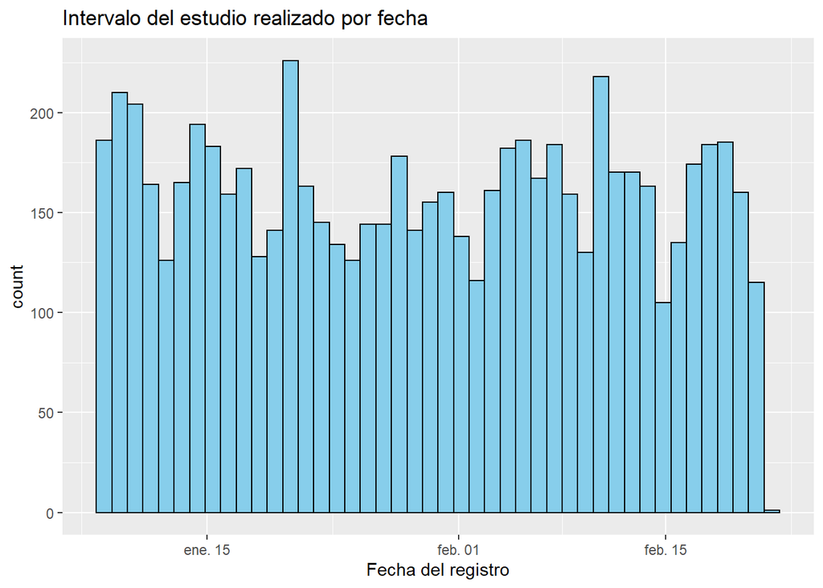

```r
raw_data %>%
  filter(servicio == "Urgencias" | servicio == "Urgencias Pediatria") %>%
  ggplot(aes(x = entrada_triage)) +
  geom_histogram(bins = 44, color = "black", fill = "skyblue") +
  labs(title = "Intervalo del estudio realizado por fecha",
       x = "Fecha del registro")
```

Interval: 2020-01-07 12:51:12 to 2020-02-21 17:00:00

## 2.2 Hourly distribution by service

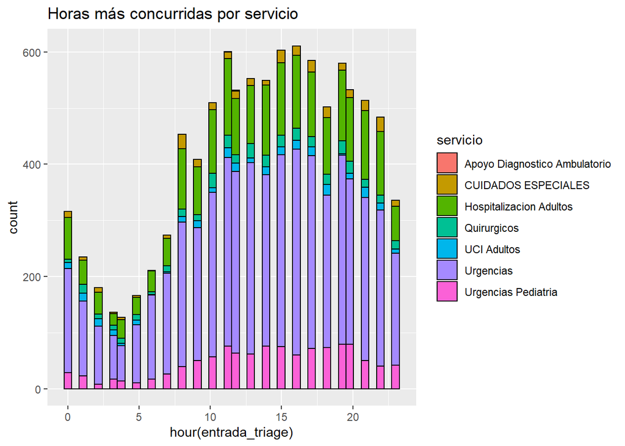

```r
raw_data %>%
  ggplot(aes(x = hour(entrada_triage), fill = servicio)) +
  geom_histogram(bins = 44, color = "black") +
  labs(title = "Horas más concurridas por servicio")
```

# 3 Creation of the duration of events

```r
clean_data <- raw_data %>%
  distinct(salida_taquilla, .keep_all = TRUE)

tiempo_llegadas <- diff(sort(clean_data$salida_taquilla))

tiempos <- clean_data %>%
  mutate(cola_triage = entrada_triage - salida_taquilla,
         dur_triage = fin_triage - entrada_triage,
         cola_servicio = entrada_servicio - fin_triage,
         dur_servicio = salida_servicio - entrada_servicio) %>%
  mutate_at(vars(cola_triage, dur_triage, cola_servicio, dur_servicio), as.numeric) %>%
  dplyr::select(atencion, servicio, servicio_detalle, cola_triage,
                dur_triage, cola_servicio, dur_servicio) %>%
  filter_if(is.numeric, all_vars(. > 10)) %>% # Validado con asistenciales
  filter(cola_triage <= 14400, # Hasta 4 horas, validado con doctores de urgencias
         cola_servicio <= 43200) # Hasta 24 horas, validado con asistenciales
```

## 3.1 A tidy version of the clean data

```r
tidy_tiempos <- tiempos %>%
  pivot_longer(cols = 4:7,
               names_to = "clase",
               values_to = "valor")

tidy_tiempos %>%
  head()
```

| atencion | servicio | servicio_detalle | clase | valor |
| --- | --- | --- | --- | --- |
| 5179578 | Urgencias | Camillas SAI Adultos | cola_triage | 237.793 |
| 5179578 | Urgencias | Camillas SAI Adultos | dur_triage | 628.190 |
| 5179578 | Urgencias | Camillas SAI Adultos | cola_servicio | 31.120 |
| 5179578 | Urgencias | Camillas SAI Adultos | dur_servicio | 11394.657 |
| 5179464 | Urgencias | Fast track 3 | cola_triage | 1154.910 |
| 5179464 | Urgencias | Fast track 3 | dur_triage | 169.153 |

### 3.1.1 Considerations

# 4 Correlations and density plots

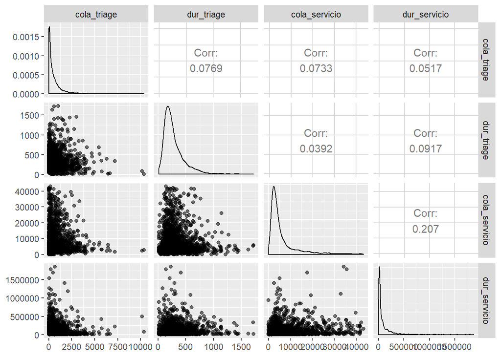

```r
tiempos %>%
  GGally::ggpairs(mapping = aes(alpha = 0.6), columns = 4:7)
```

All the event lengths seem to be uncorrelated with each other. At first glance some exponential distributions may appear.

# 5 Descriptive statistics

```r
tiempos %>%
  summary()
```

```
##     atencion         servicio         servicio_detalle    cola_triage
##  Min.   :5113114   Length:2872        Length:2872        Min.   :   10.09
##  1st Qu.:5130174   Class :character   Class :character   1st Qu.:   38.98
##  Median :5148630   Mode  :character   Mode  :character   Median :  246.44
##  Mean   :5147057                                         Mean   :  553.24
##  3rd Qu.:5164303                                         3rd Qu.:  700.08
##  Max.   :5179578                                         Max.   :10341.00
##    dur_triage      cola_servicio       dur_servicio
##  Min.   :  10.36   Min.   :   27.05   Min.   :   1025
##  1st Qu.: 152.75   1st Qu.: 2242.30   1st Qu.:  15913
##  Median : 226.44   Median : 3541.01   Median :  31996
##  Mean   : 281.00   Mean   : 6031.24   Mean   :  87525
##  3rd Qu.: 349.97   3rd Qu.: 6534.60   3rd Qu.:  96044
##  Max.   :1724.55   Max.   :42961.42   Max.   :1860358
```

## 5.1 Histograms

### 5.1.1 Tiempo entre llegadas

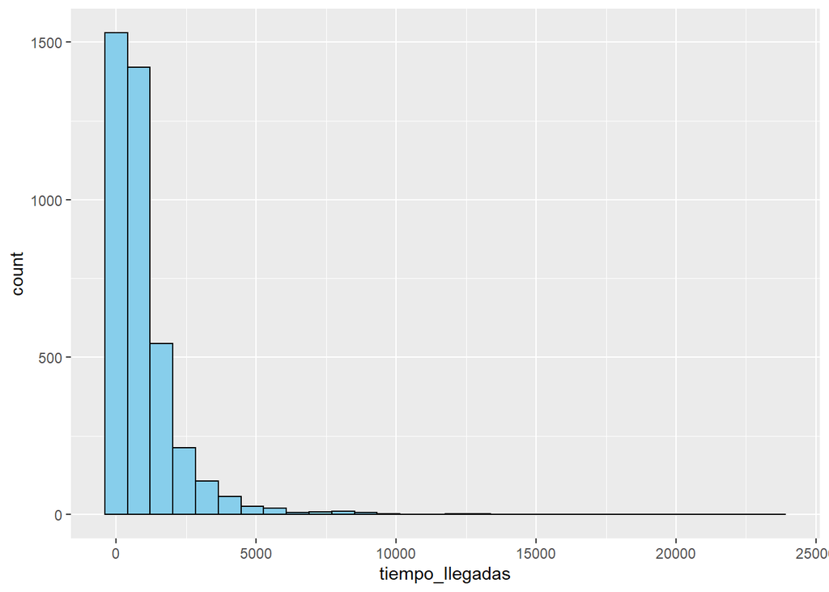

```r
tibble(tiempo_llegadas) %>%
  ggplot(aes(x = tiempo_llegadas)) +
  geom_histogram(color = "black", fill = "skyblue")
```

Generales

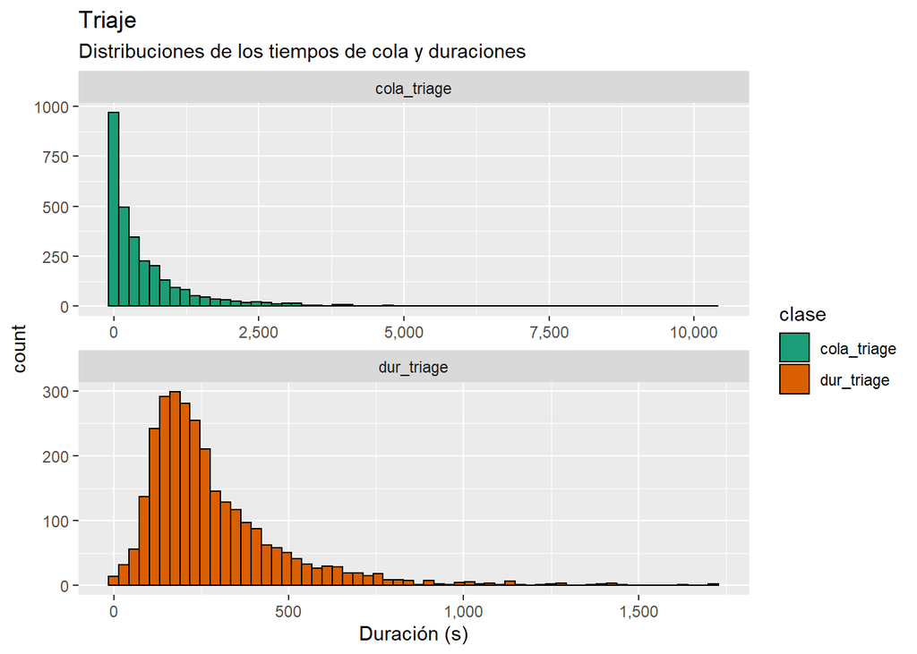

```r
triaje <- tidy_tiempos %>%
  filter(clase == "cola_triage" | clase == "dur_triage")

triaje %>%
  ggplot(aes(x = valor, fill = clase)) +
  geom_histogram(color = "black", bins = 60) +
  facet_wrap(~clase, scales = "free", nrow = 2) +
  scale_x_continuous(labels = scales::comma) +
  scale_fill_brewer(palette = "Dark2") +
    labs(title = "Triaje",
     subtitle = "Distribuciones de los tiempos de cola y duraciones",
     x = "Duración (s)")
```

```r
triaje %>%
  filter(clase == "dur_triage") %>%
  summarize(media = mean(valor), varianza = var(valor), sd = sd(valor), min = min(valor), max = max(valor))
```

| media | varianza | sd | min | max |
| --- | --- | --- | --- | --- |
| 281.0015 | 39041.46 | 197.5891 | 10.36 | 1724.55 |

### 5.1.2 SAI Adultos

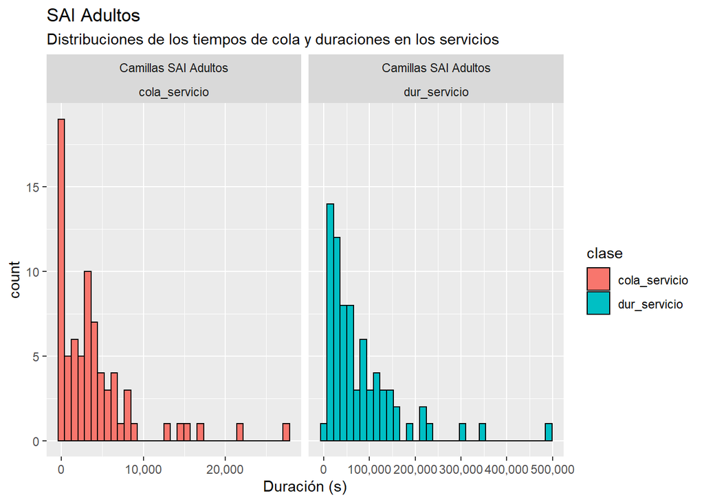

```r
sai <- tidy_tiempos %>%
  filter(servicio_detalle == "Camillas SAI Adultos",
         clase == "cola_servicio" | clase == "dur_servicio")

sai %>%
  ggplot(aes(x = valor, fill = clase)) +
  geom_histogram(color = "black", bins = 35) +
  facet_wrap(~servicio_detalle + clase, scales = "free_x", ncol = 2) +
  scale_x_continuous(labels = scales::comma) +
  labs(title = "SAI Adultos",
    subtitle = "Distribuciones de los tiempos de cola y duraciones en los servicios",
    x = "Duración (s)")
```

```r
sai %>%
  filter(clase == "dur_servicio") %>%
  summarize(media = mean(valor), varianza = var(valor), sd = sd(valor), min = min(valor), max = max(valor))
```

| media | varianza | sd | min | max |
| --- | --- | --- | --- | --- |
| 81241.28 | 7135323006 | 84470.84 | 4657.31 | 496272.7 |

### 5.1.3 Trauma

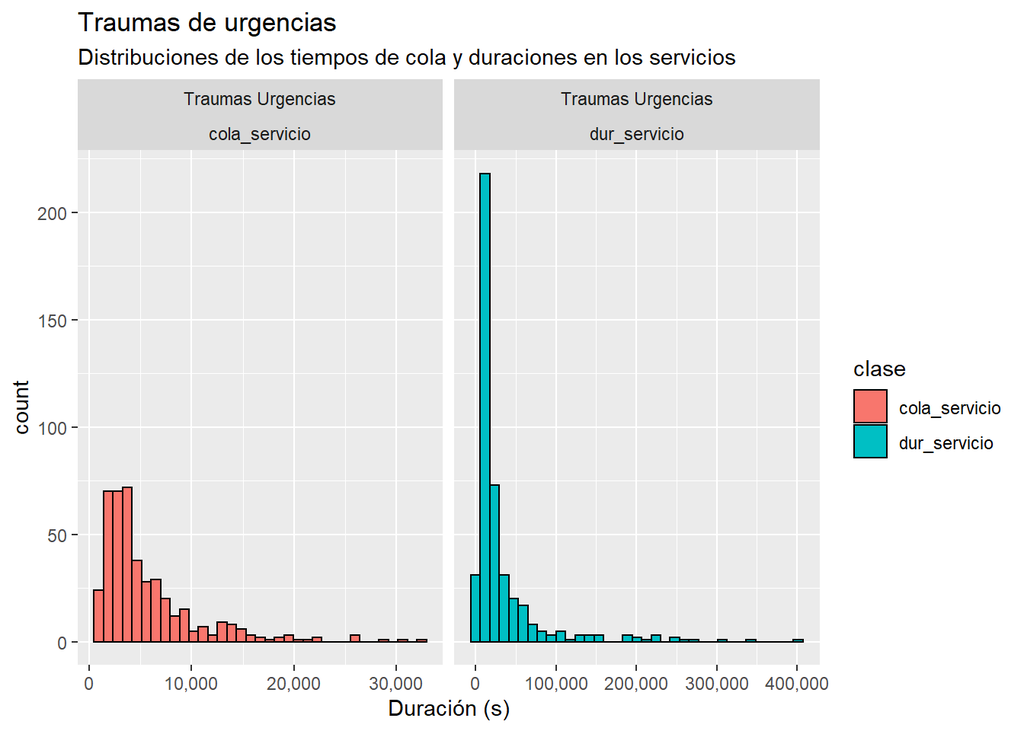

```r
trauma <- tidy_tiempos %>%
  filter(servicio_detalle == "Traumas Urgencias",
         clase == "cola_servicio" | clase == "dur_servicio")

trauma %>%
  ggplot(aes(x = valor, fill = clase)) +
  geom_histogram(color = "black", bins = 35) +
  facet_wrap(~servicio_detalle + clase, scales = "free_x", ncol = 2) +
  scale_x_continuous(labels = scales::comma) +
  labs(title = "Traumas de urgencias",
    subtitle = "Distribuciones de los tiempos de cola y duraciones en los servicios",
    x = "Duración (s)")
```

```r
trauma %>%
  filter(clase == "dur_servicio") %>%
  summarize(media = mean(valor), varianza = var(valor), sd = sd(valor), min = min(valor), max = max(valor))
```

| media | varianza | sd | min | max |
| --- | --- | --- | --- | --- |
| 32690.49 | 2551067712 | 50508.1 | 1896.56 | 403266.7 |

### 5.1.4 Consultorio adultos

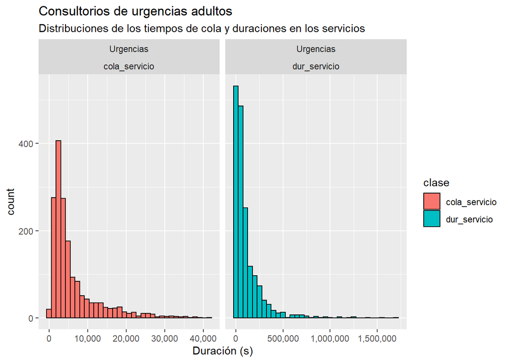

```r
adultos <- tidy_tiempos %>%
  filter(servicio == "Urgencias",
         servicio_detalle != "Traumas Urgencias",
         servicio_detalle != "Camillas SAI Adultos",
         clase == "cola_servicio" | clase == "dur_servicio")

adultos %>%
  ggplot(aes(x = valor, fill = clase)) +
  geom_histogram(color = "black", bins = 35) +
  facet_wrap(~servicio + clase, scales = "free_x", ncol = 2) +
  scale_x_continuous(labels = scales::comma) +
  labs(title = "Consultorios de urgencias adultos",
    subtitle = "Distribuciones de los tiempos de cola y duraciones en los servicios",
    x = "Duración (s)")
```

```r
adultos %>%
  filter(clase == "dur_servicio") %>%
  summarize(media = mean(valor), varianza = var(valor), sd = sd(valor), min = min(valor), max = max(valor))
```

| media | varianza | sd | min | max |
| --- | --- | --- | --- | --- |
| 108025.2 | 24544310347 | 156666.2 | 1024.626 | 1700253 |

### 5.1.5 Pediatría

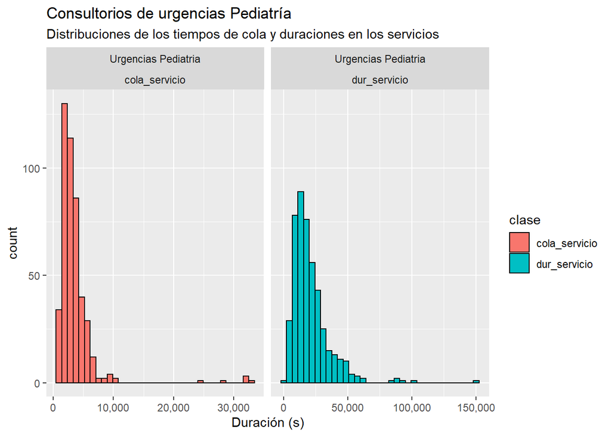

```r
pediatria <- tidy_tiempos %>%
  filter(servicio_detalle == "ERA Pediatria",
         clase == "cola_servicio" | clase == "dur_servicio")

pediatria %>%
  ggplot(aes(x = valor, fill = clase)) +
  geom_histogram(color = "black", bins = 35) +
  facet_wrap(~servicio + clase, scales = "free_x", ncol = 2) +
  scale_x_continuous(labels = scales::comma) +
  labs(title = "Consultorios de urgencias Pediatría",
    subtitle = "Distribuciones de los tiempos de cola y duraciones en los servicios",
    x = "Duración (s)")
```

```r
pediatria %>%
  filter(clase == "dur_servicio") %>%
  summarize(media = mean(valor), varianza = var(valor), sd = sd(valor), min = min(valor), max = max(valor))
```

| media | varianza | sd | min | max |
| --- | --- | --- | --- | --- |
| 20853.1 | 225545395 | 15018.17 | 2124.21 | 152414.7 |

# 6 Distribution selection

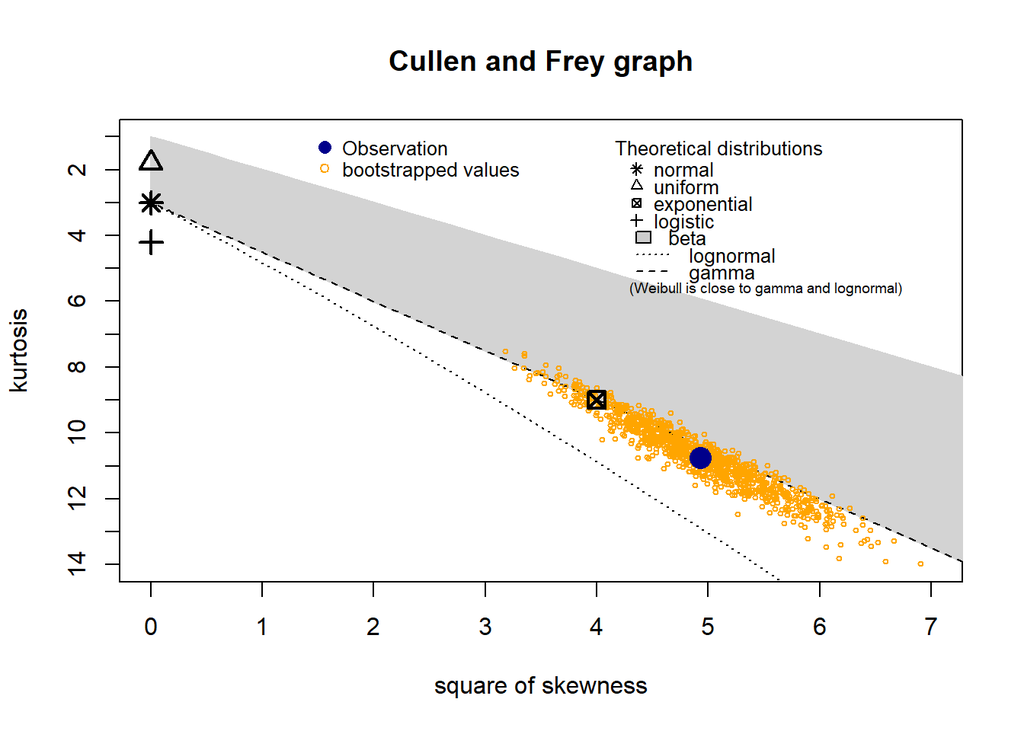

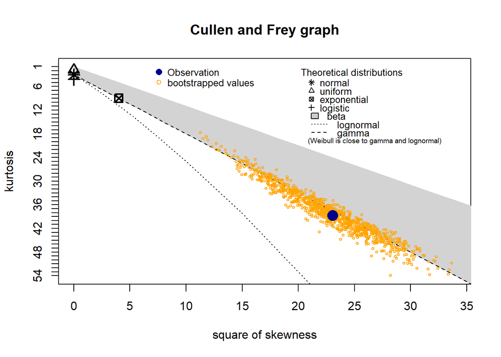

```r
cullen_fray <- map(tiempos[,c(5,7)], descdist, discrete = FALSE, boot = 1000)
```

```r
cullen_fray
```

```
## $dur_triage
## summary statistics
## ------
## min:  10.36   max:  1724.55
## median:  226.442
## mean:  281.0015
## estimated sd:  197.5891
## estimated skewness:  2.220981
## estimated kurtosis:  10.7491
##
## $dur_servicio
## summary statistics
## ------
## min:  1024.626   max:  1860358
## median:  31995.47
## mean:  87524.79
## estimated sd:  145817.7
## estimated skewness:  4.801057
## estimated kurtosis:  38.70562
```

```r
cullen_fray_llegadas <- descdist(as.numeric(tiempo_llegadas), boot = 1000)
```

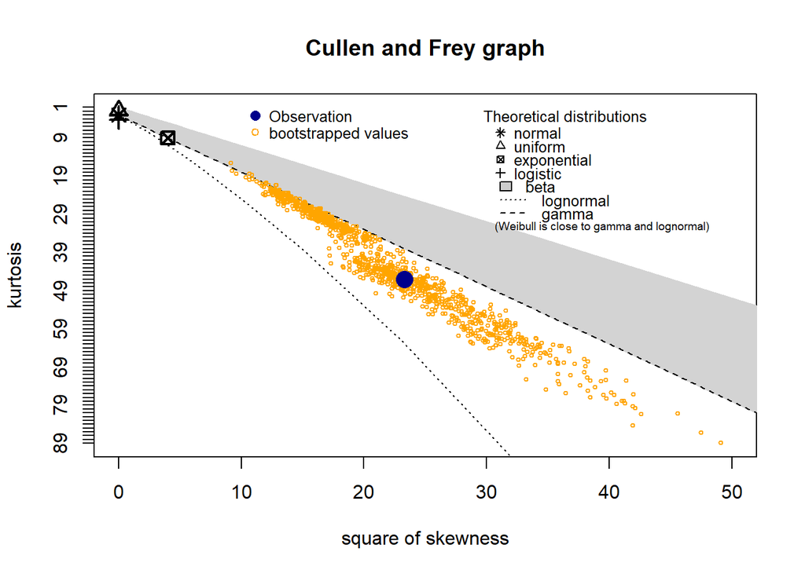

```r
cullen_fray_llegadas
```

```
## summary statistics
## ------
## min:  0.6399999   max:  23510.01
## median:  583.113
## mean:  984.6885
## estimated sd:  1332.919
## estimated skewness:  4.827311
## estimated kurtosis:  46.06959
```

Distributions will only be fitted to the duration of the services, as the queues are of no interest, but rather an output of the discrete event simulation.

# 7 Distribution fitting and hypothesis testing

In this part, several distribution will be tried for every service, based on the recommendations obtained with the Cullen and Frey method, further reference can be obtained in: Cullen AC and Frey HC (1999), Probabilistic techniques in exposure assessment. Plenum Press, USA, pp. 81-159.

## 7.1 Triage duration

Exponential distribution, gamma distribution and lognormal distribution are good candiadates for the data based on the kurtosis (10.7491014) and skewness (2.2209812) of the data.

### 7.1.1 Exponential distribution

```r
fit_triage_exp <- fitdist(tiempos$dur_triage, distr = "exp", method = "mle")
fit_triage_exp
```

```
## Fitting of the distribution ' exp ' by maximum likelihood
## Parameters:
##       estimate   Std. Error
## rate 0.0035587 6.057445e-05
```

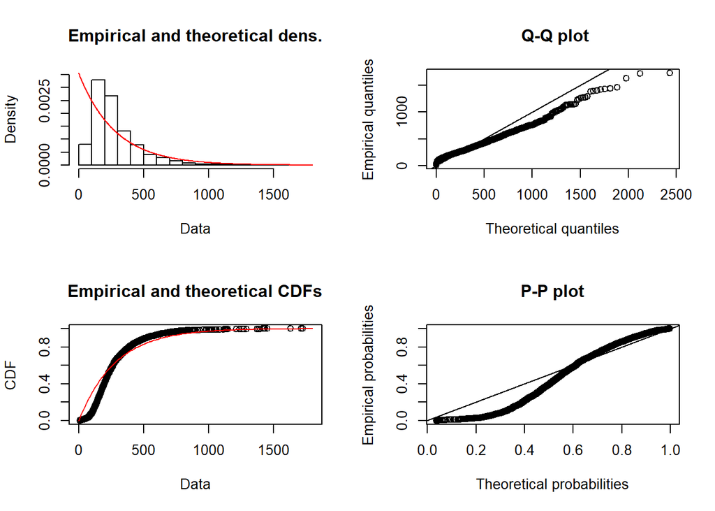

```r
plot(fit_triage_exp)
```

Null hyphotesis rejected based on the Q-Q plot, the data can’t possibly be represented by an exponential distribution.

### 7.1.2 Gamma distribution

```r
fit_triage_gamma <- fitdist(tiempos$dur_triage, distr = "gamma", method = "mle")
fit_triage_gamma
```

```
## Fitting of the distribution ' gamma ' by maximum likelihood
## Parameters:
##          estimate  Std. Error
## shape 2.532456026 0.060685143
## rate  0.009012918 0.000235833
```

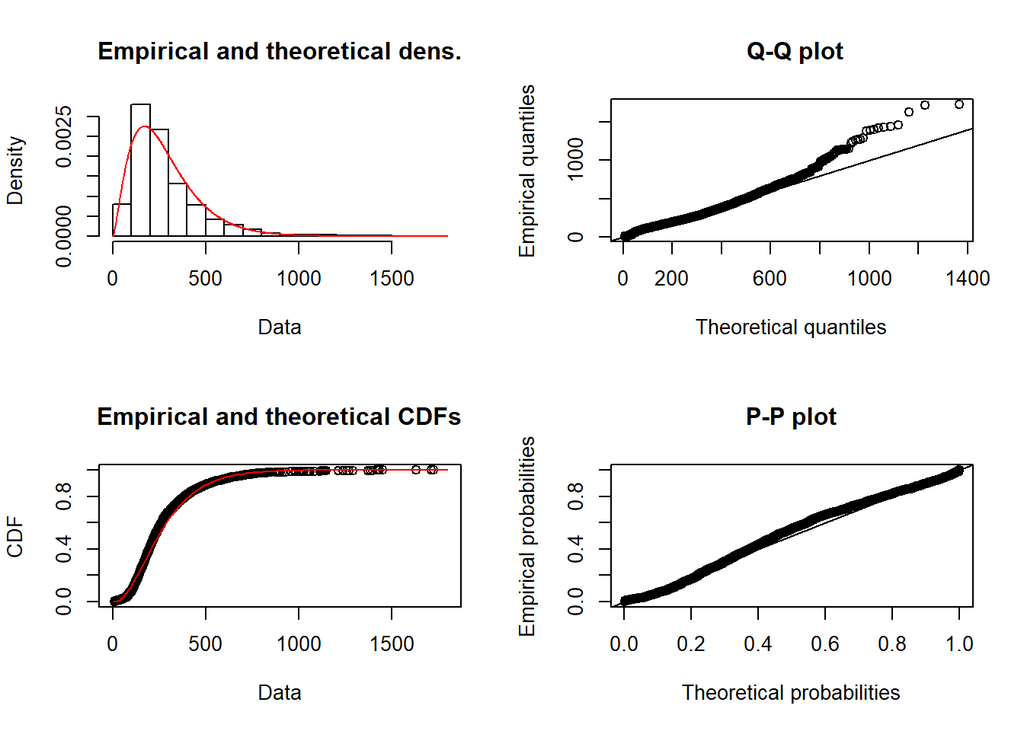

```r
plot(fit_triage_gamma)
```

Null hyphotesis could be rejected, need further testing.

### 7.1.3 Lognormal

```r
fit_triage_lognormal <- fitdist(tiempos$dur_triage, distr = "lnorm", method = "mle")
fit_triage_lognormal
```

```
## Fitting of the distribution ' lnorm ' by maximum likelihood
## Parameters:
##          estimate  Std. Error
## meanlog 5.4281722 0.012517019
## sdlog   0.6708001 0.008850781
```

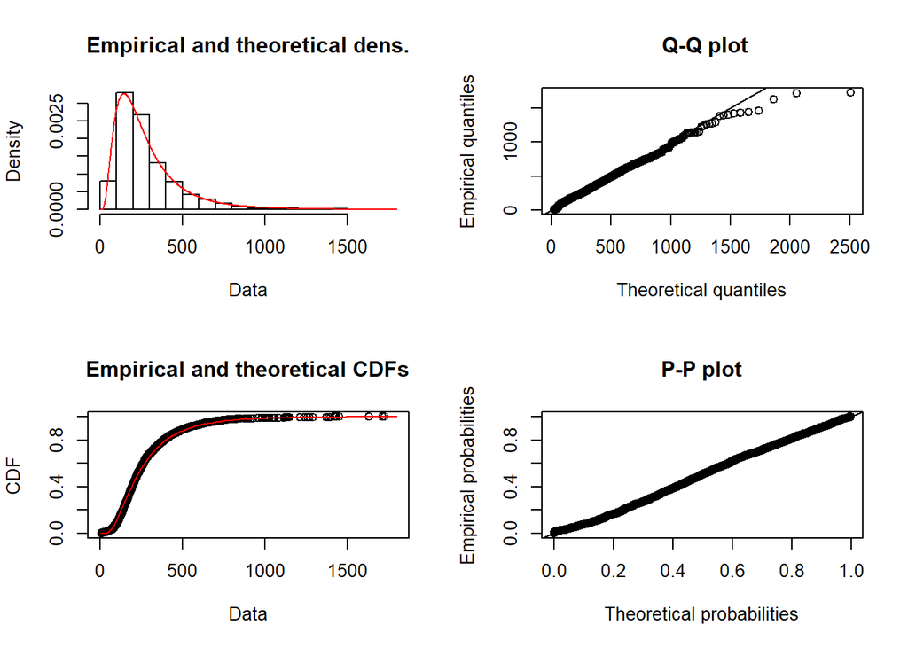

```r
plot(fit_triage_lognormal)
```

Data is definitely lognormal, need to conduct formal hypothesis testing here.

## 7.2 Service duration

The services are individual, so an aggregation of these doesn’t seem appropiate at all. The individual services are:

| servicio | n |
| --- | --- |
| Urgencias | 2223 |
| Urgencias Pediatria | 575 |
| Hospitalizacion Adultos | 34 |
| Quirurgicos | 21 |
| UCI Adultos | 11 |
| CUIDADOS ESPECIALES | 8 |

A general try to the aggregated services: Note that this is incorrect, as triage dynamics are hidden inside the data.

Gamma distribution and lognormal distribution could be good candiadates for the data based on the kurtosis (38.7056184) and skewness (4.8010565) of the data using Cullen and Frey’s graphical method.

### 7.2.1 Gamma distribution

Changing the scale of the data doesn’t affect it’s distribution as long as it remains positive and every number is scaled. This helps the Maximum likelihood Stimation to converge.

```r
fit_servicio_gamma <- fitdist(tiempos$dur_servicio/250, distr = "gamma", method = "mle")
fit_servicio_gamma
```

```
## Fitting of the distribution ' gamma ' by maximum likelihood
## Parameters:
##          estimate   Std. Error
## shape 0.760136694 1.391795e-02
## rate  0.002171234 3.666788e-05
```

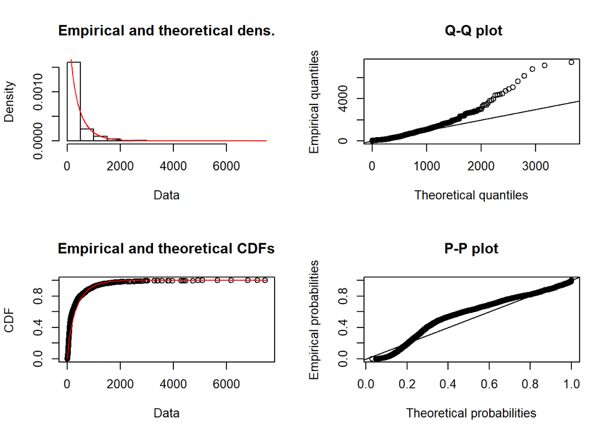

```r
plot(fit_servicio_gamma)
```

Gamma distribution doesn’t seem to work very well with this data. May need more tunning.

### 7.2.2 Lognormal distribution

```r
fit_servicio_lognormal <- fitdist(tiempos$dur_servicio, distr = "lnorm", method = "mle")
fit_servicio_lognormal
```

```
## Fitting of the distribution ' lnorm ' by maximum likelihood
## Parameters:
##          estimate Std. Error
## meanlog 10.593692 0.02272588
## sdlog    1.217904 0.01606957
```

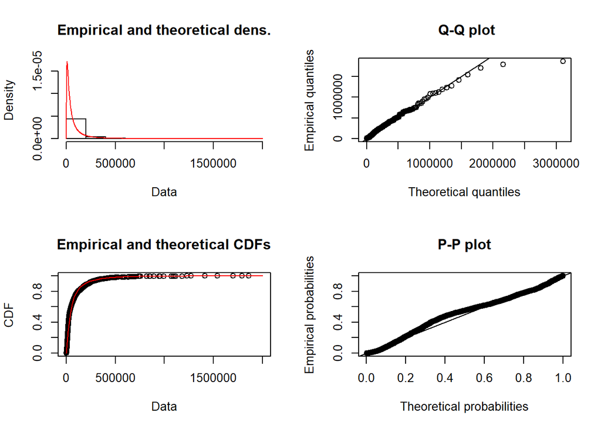

```r
plot(fit_servicio_lognormal)
```

Lognormal distribution may work, need further verification. Theorically there is no distribution that can fit these data, as there are distinguishable categories that behave differently inside the data. Separation by service and triage is needed.

Therefore, the following code creates subsets that only include the particular services of interest.

## 7.3 Camillas SAI Adultos

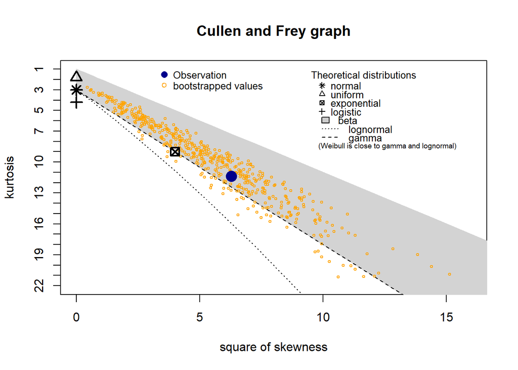

```
## summary statistics
## ------
## min:  4657.31   max:  496272.7
## median:  57801.73
## mean:  81241.28
## estimated sd:  84470.84
## estimated skewness:  2.50566
## estimated kurtosis:  11.38377
```

```r
tiempos_SAI <- tiempos %>%
  filter(servicio_detalle == "Camillas SAI Adultos")

descdist(as.numeric(tiempos_SAI$dur_servicio), boot = 500)
```

### 7.3.1 Exponential

```r
fit_SAI_exp <- fitdist(tiempos_SAI$dur_servicio/250, distr = "exp", method = "mle")
fit_SAI_exp
```

```
## Fitting of the distribution ' exp ' by maximum likelihood
## Parameters:
##         estimate   Std. Error
## rate 0.003077253 0.0003138134
```

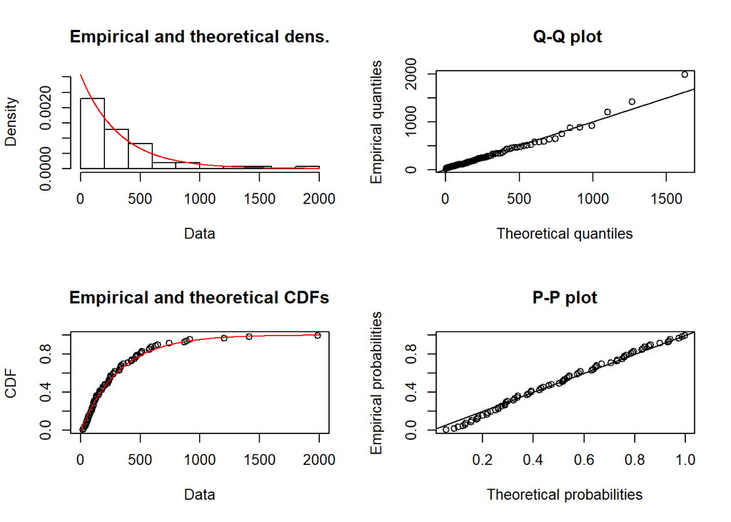

```r
plot(fit_SAI_exp)
```

### 7.3.2 Lognormal

```r
fit_SAI_lognormal <- fitdist(tiempos_SAI$dur_servicio, distr = "lnorm", method = "mle")
fit_SAI_lognormal
```

```
## Fitting of the distribution ' lnorm ' by maximum likelihood
## Parameters:
##           estimate Std. Error
## meanlog 10.8619681 0.11296381
## sdlog    0.9717514 0.07987709
```

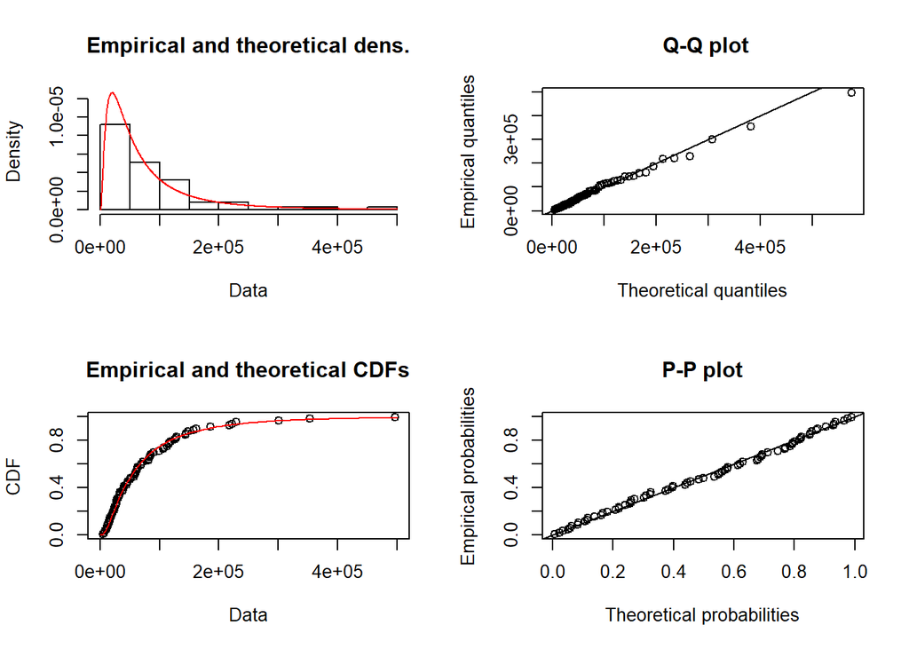

```r
plot(fit_SAI_lognormal)
```

### 7.3.3 Gamma distribution

Need an scaling factor for the gamma to work, **need to reference this.**

```r
fit_SAI_gamma <- fitdist(tiempos_SAI$dur_servicio/250, distr = "gamma", method = "mle")
fit_SAI_gamma
```

```
## Fitting of the distribution ' gamma ' by maximum likelihood
## Parameters:
##          estimate   Std. Error
## shape 1.268726401 0.1710003944
## rate  0.003903499 0.0005959129
```

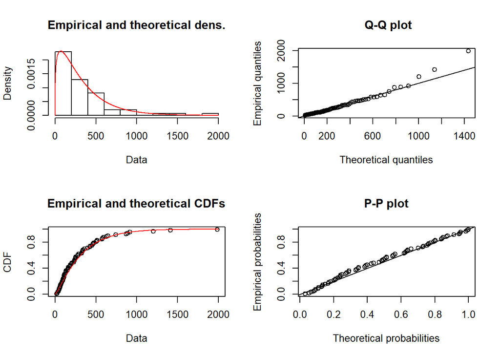

```r
plot(fit_SAI_gamma)
```

## 7.4 Traumas Urgencias

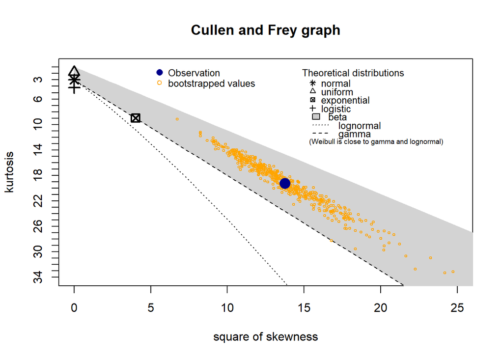

```
## summary statistics
## ------
## min:  1896.56   max:  403266.7
## median:  15546.78
## mean:  32690.49
## estimated sd:  50508.1
## estimated skewness:  3.709115
## estimated kurtosis:  19.23004
```

```r
tiempos_trauma <- tiempos %>%
  filter(servicio_detalle == "Traumas Urgencias")

descdist(as.numeric(tiempos_trauma$dur_servicio), boot = 500)
```

### 7.4.1 Exponential

```r
fit_trauma_exp <- fitdist(tiempos_trauma$dur_servicio/250, distr = "exp", method = "mle")
fit_trauma_exp
```

```
## Fitting of the distribution ' exp ' by maximum likelihood
## Parameters:
##         estimate  Std. Error
## rate 0.007647485 0.000359444
```

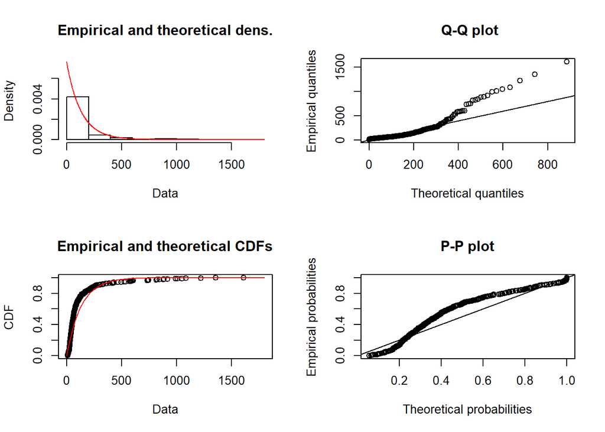

```r
plot(fit_trauma_exp)
```

No.

### 7.4.2 Lognormal

```r
fit_trauma_lognormal <- fitdist(tiempos_trauma$dur_servicio, distr = "lnorm", method = "mle")
fit_trauma_lognormal
```

```
## Fitting of the distribution ' lnorm ' by maximum likelihood
## Parameters:
##          estimate Std. Error
## meanlog 9.8113405 0.04661073
## sdlog   0.9743761 0.03295861
```

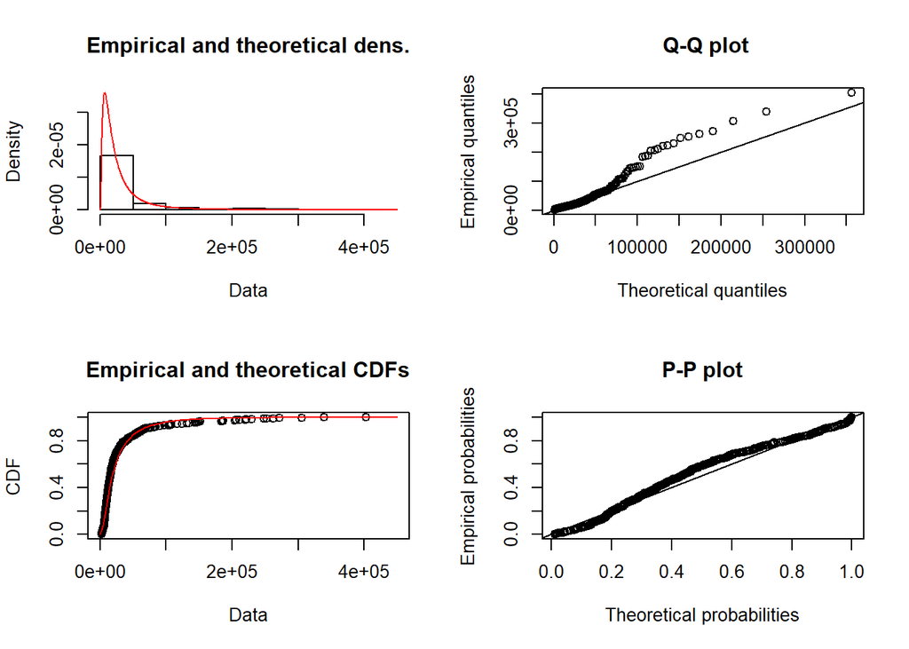

```r
plot(fit_trauma_lognormal)
```

No.

### 7.4.3 Gamma distribution

Need an scaling factor for the gamma to work, **need to reference this.**

```r
fit_trauma_gamma <- fitdist(tiempos_trauma$dur_servicio/250, distr = "gamma", method = "mle")
fit_trauma_gamma
```

```
## Fitting of the distribution ' gamma ' by maximum likelihood
## Parameters:
##          estimate   Std. Error
## shape 0.990216900 0.0578801335
## rate  0.007572023 0.0005588176
```

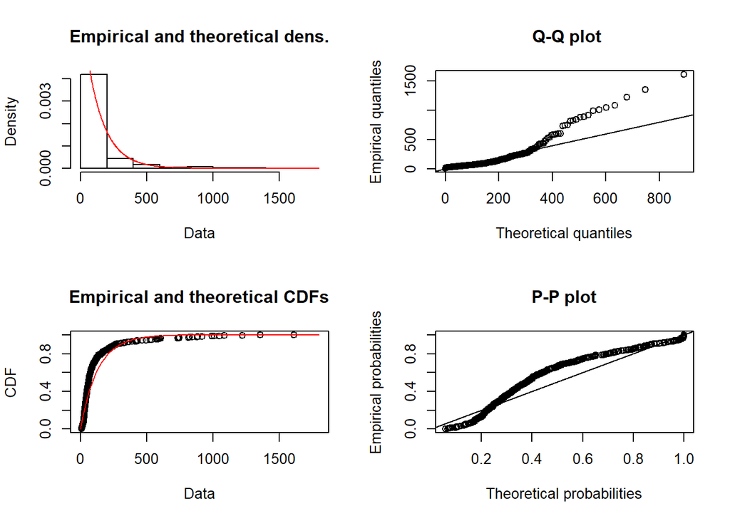

```r
plot(fit_trauma_gamma)
```

No.

## 7.5 ERA Pediatria

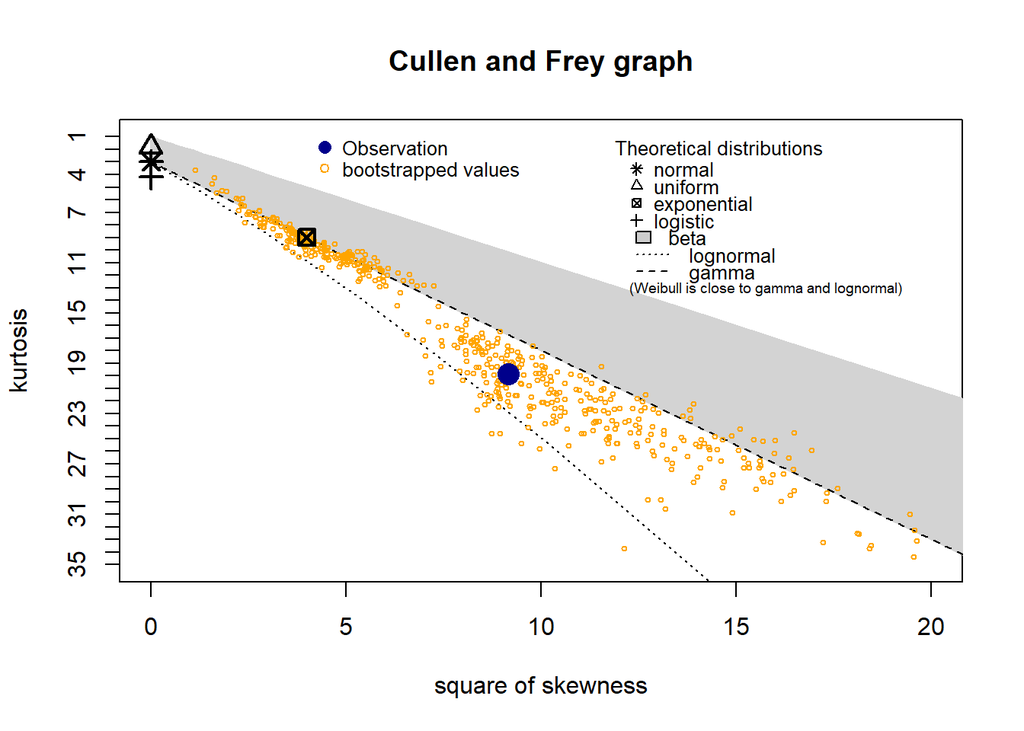

```
## summary statistics
## ------
## min:  2124.21   max:  152414.7
## median:  17422.22
## mean:  20853.1
## estimated sd:  15018.17
## estimated skewness:  3.028491
## estimated kurtosis:  19.84837
```

```r
tiempos_pediatria <- tiempos %>%
  filter(servicio_detalle == "ERA Pediatria")

descdist(as.numeric(tiempos_pediatria$dur_servicio), boot = 500)
```

### 7.5.1 Exponential

```r
fit_pediatria_exp <- fitdist(tiempos_pediatria$dur_servicio/250, distr = "exp", method = "mle")
fit_pediatria_exp
```

```
## Fitting of the distribution ' exp ' by maximum likelihood
## Parameters:
##        estimate   Std. Error
## rate 0.01198862 0.0005544489
```

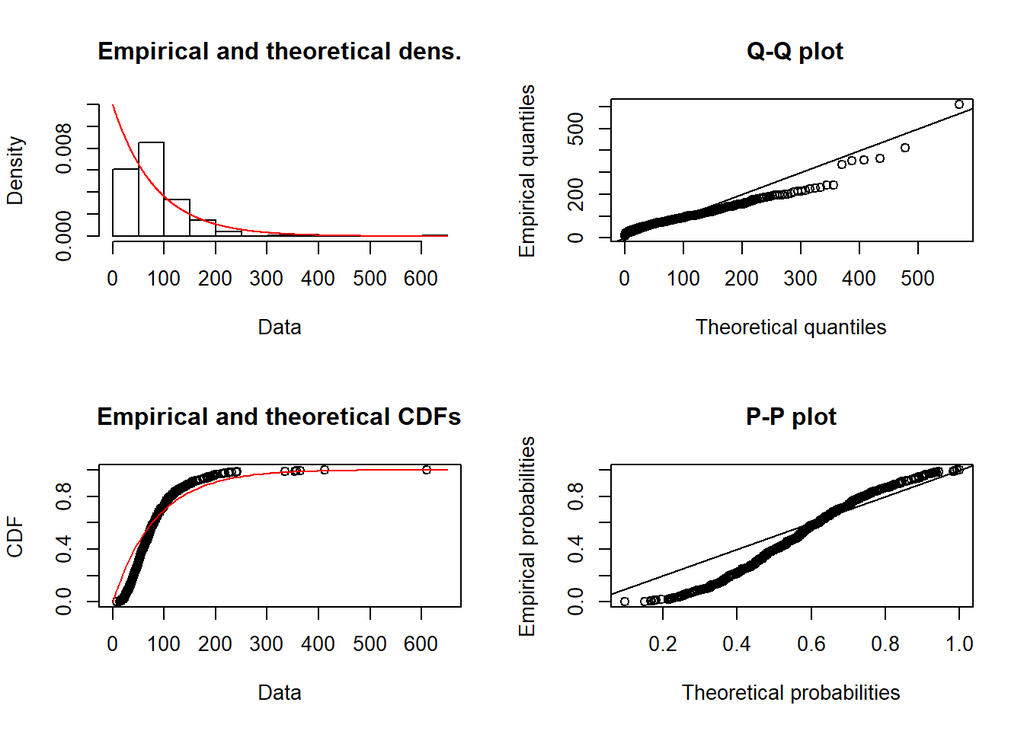

```r
plot(fit_pediatria_exp)
```

No.

### 7.5.2 Lognormal

```r
fit_pediatria_lognormal <- fitdist(tiempos_pediatria$dur_servicio, distr = "lnorm", method = "mle")
fit_pediatria_lognormal
```

```
## Fitting of the distribution ' lnorm ' by maximum likelihood
## Parameters:
##          estimate Std. Error
## meanlog 9.7505951 0.02879642
## sdlog   0.6182853 0.02036190
```

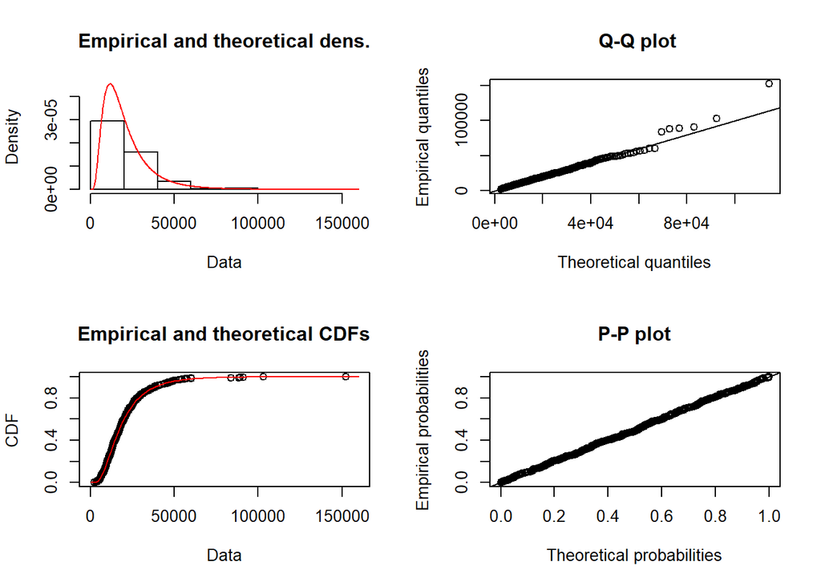

```r
plot(fit_pediatria_lognormal)
```

Parece que sí

### 7.5.3 Gamma distribution

Need an scaling factor for the gamma to work, **need to reference this.**

```r
fit_pediatria_gamma <- fitdist(tiempos_pediatria$dur_servicio/250, distr = "gamma", method = "mle")
fit_pediatria_gamma
```

```
## Fitting of the distribution ' gamma ' by maximum likelihood
## Parameters:
##         estimate  Std. Error
## shape 2.72363406 0.169047595
## rate  0.03264779 0.002222735
```

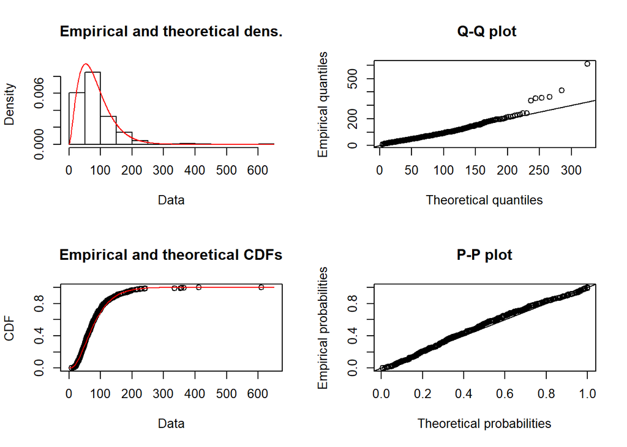

```r
plot(fit_pediatria_gamma)
```

No.

In case a triangular distribution was needed you could do:

`fit_pediatria_triangular <- fitdist(tiempos_pediatria$dur_servicio, distr = "triang", method = "mge", start = list(min=0, mode=25000,max=100000), gof = "CvM")`

## 7.6 Consultorios adultos

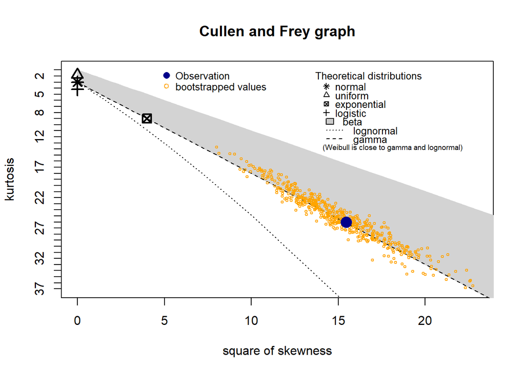

```
## summary statistics
## ------
## min:  1024.626   max:  1700253
## median:  52251.09
## mean:  108025.2
## estimated sd:  156666.2
## estimated skewness:  3.931336
## estimated kurtosis:  26.00525
```

```r
tiempos_adultos <- tiempos %>%
  filter(servicio == "Urgencias",
         servicio_detalle != "Traumas Urgencias",
         servicio_detalle != "Camillas SAI Adultos")

descdist(as.numeric(tiempos_adultos$dur_servicio), boot = 500)
```

### 7.6.1 Exponential

```r
fit_adultos_exp <- fitdist(tiempos_adultos$dur_servicio/250, distr = "exp", method = "mle")
fit_adultos_exp
```

```
## Fitting of the distribution ' exp ' by maximum likelihood
## Parameters:
##         estimate   Std. Error
## rate 0.002314274 4.124049e-05
```

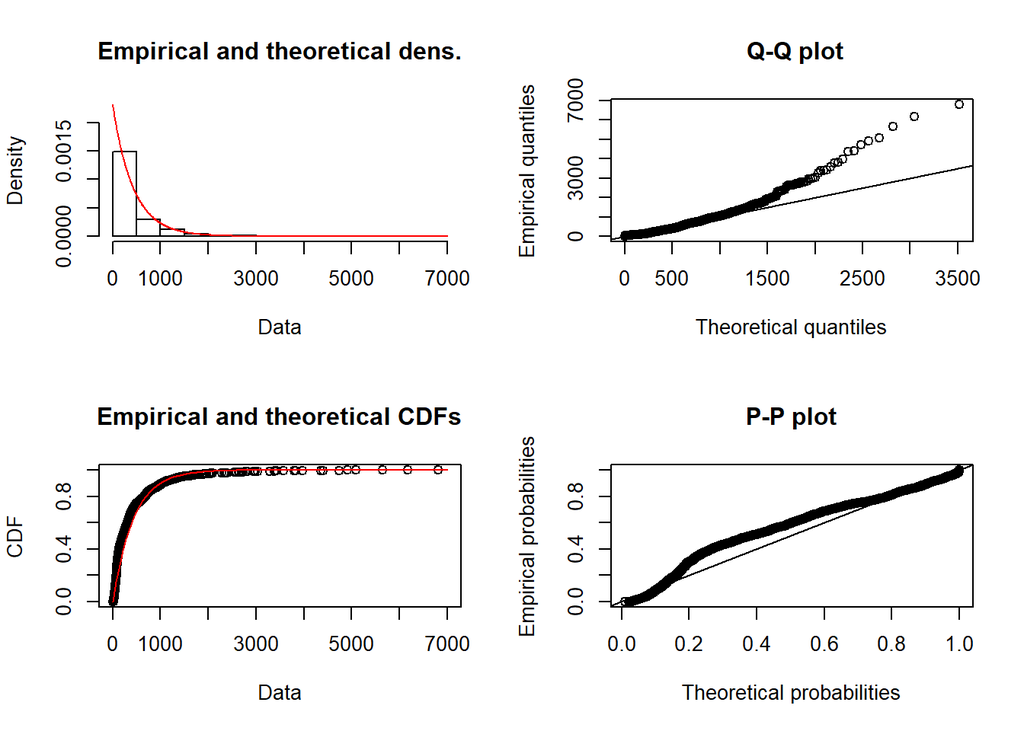

```r
plot(fit_adultos_exp)
```

No.